# Oil Reservoir Data

Mark and Quynh

October 3, 2016

## Data Source

```r
df = readRDS('../01 Data/dataframe.rds')
# Display a subset and summary of the data frame
summary(df)
```

```
##            STATE                    FLDNAME         RESNAME      R_STUDY
##  LOUISIANA    :9005   WEST DELTA BLK 30 :  114   358CLNN:  186   A:13531
##  TEXAS        :5363   BAY MARCHAND BLK 2:  103   NO NAME:  150   R: 1255
##  OKLAHOMA     : 736   GRAND ISLE BLK 43 :   92   339BERE:  138   T: 4434
##  WEST VIRGINIA: 696   SHIP SHOAL BLK 113:   82   330MSSP:  134
##  PENNSYLVANIA : 543   SOUTH PASS BLK 27 :   80   332BGLM:  131
##  OHIO         : 535   SHIP SHOAL BLK 176:   64   MORROW :  122
##  (Other)      :2342   (Other)           :18685   (Other):18359
##                                                  PLAYNAME
##  null                                                : 1289
##  LOWER PLEISTOCENE PROGRADATIONAL SANDSTONE          : 1229
##  UPPER UPPER MIOCENE EASTERN PROGRADATIONAL SANDSTONE: 1080
##  LOWER PLIOCENE EASTERN PROGRADATIONAL SANDSTONE     :  682
##  UPPER PLIOCENE PROGRADATIONAL SANDSTONE             :  660
##  MIDDLE PLEISTOCENE PROGRADATIONAL SANDSTONE         :  653
##  (Other)                                             :13627
##      PLAYCOD            ERANM       SUBPLAYN               SYSNM
##  null    : 1288   CENOZOIC :11658   null:19220   TERTIARY     :7947
##  LPL P.1 : 1229   MESOZOIC : 1223                QUATERNARY   :3711
##  UM3 P.1B: 1080   null     : 1517                null         :1521
##  LP P.1B :  682   PALEOZOIC: 4821                PENNSYLVANIAN:1373
##  UP P.1  :  660   PALEOZOK :    1                MISSISSIPPIAN:1138
##  MPL P.1 :  653                                  DEVONIAN     :1108
##  (Other) :13628                                  (Other)      :2422
##             SERNM       S_POR        S_PERM          LINKA
##  MIOCENE       :4359   A   :10449   A   :  465   Min.   :    1
##  PLEISTOCENE   :3710   null: 5815   null:16949   1st Qu.: 4806
##  null          :2543   R   : 1216   R   :   53   Median : 9610
##  PLIOCENE      :1913   T   : 1740   T   : 1753   Mean   : 9610
##  OLIGOCENE     :1129                             3rd Qu.:14415
##  UPPER DEVONIAN: 718                             Max.   :19220
##  (Other)       :4848
##      AVPOR           LOPOR             HIPOR            AVPERM
##  Min.   : 0.00   Min.   : 0.0000   Min.   : 0.000   Min.   :   0.00
##  1st Qu.: 0.00   1st Qu.: 0.0000   1st Qu.: 0.000   1st Qu.:   0.00
##  Median :22.00   Median : 0.0000   Median : 0.000   Median :   0.00
##  Mean   :16.71   Mean   : 0.5727   Mean   : 1.904   Mean   :  27.61
##  3rd Qu.:29.00   3rd Qu.: 0.0000   3rd Qu.: 0.000   3rd Qu.:   0.00
##  Max.   :98.00   Max.   :33.0000   Max.   :43.000   Max.   :8200.00
##
##      LOPERM             HIPERM           RESTEMP
##  Min.   :   0.000   Min.   :    0.0   Min.   :  0.0
##  1st Qu.:   0.000   1st Qu.:    0.0   1st Qu.:  0.0
##  Median :   0.000   Median :    0.0   Median :135.0
##  Mean   :   2.188   Mean   :   32.3   Mean   :111.6
##  3rd Qu.:   0.000   3rd Qu.:    0.0   3rd Qu.:184.0
##  Max.   :4016.000   Max.   :27412.0   Max.   :414.0
##
```

```r
head(df)
```

```
##     STATE            FLDNAME   RESNAME R_STUDY
## 1 ALABAMA           ALOE BAY  NORPHLET       A
## 2 ALABAMA          BEAVERTON CARTER NE       R
## 3 ALABAMA          BEAVERTON CARTER SE       R
## 4 ALABAMA          BEAVERTON     LEWIS       R
## 5 ALABAMA      BETHEL CHURCH    CARTER       R
## 6 ALABAMA BIG ESCAMBIA CREEK SMACKOVER       T
##                                                                                 PLAYNAME
## 1                                                 UPPER JURASSIC AGGRADATIONAL SANDSTONE
## 2 PENNSYLVANIAN-MISSISSIPPIAN DELTAIC AND MARINE SHELF SANDSTONE-ALABAMA AND MISSISSIPPI
## 3 PENNSYLVANIAN-MISSISSIPPIAN DELTAIC AND MARINE SHELF SANDSTONE-ALABAMA AND MISSISSIPPI
## 4 PENNSYLVANIAN-MISSISSIPPIAN DELTAIC AND MARINE SHELF SANDSTONE-ALABAMA AND MISSISSIPPI
## 5 PENNSYLVANIAN-MISSISSIPPIAN DELTAIC AND MARINE SHELF SANDSTONE-ALABAMA AND MISSISSIPPI
## 6                     UPPER JURASSIC SHALLOW-MARINE CARBONATE AND SANDSTONE-MAFLA REGION
##     PLAYCOD     ERANM SUBPLAYN         SYSNM            SERNM S_POR S_PERM
## 1    UU A.1  MESOZOIC     null      JURASSIC   UPPER JURASSIC     A   null
## 2 GCPN-MS-1 PALEOZOIC     null MISSISSIPPIAN UPPER CHESTERIAN     R   null
## 3 GCPN-MS-1 PALEOZOIC     null MISSISSIPPIAN UPPER CHESTERIAN     R   null
## 4 GCPN-MS-1 PALEOZOIC     null MISSISSIPPIAN UPPER CHESTERIAN     R   null
## 5 GCPN-MS-1 PALEOZOIC     null MISSISSIPPIAN UPPER CHESTERIAN     R   null
## 6    GCJC-3  MESOZOIC     null      JURASSIC   UPPER JURASSIC     T      T
##   LINKA AVPOR LOPOR HIPOR AVPERM LOPERM HIPERM RESTEMP
## 1     1  11.0     0     0      0      0      0       0
## 2     2  15.6    13    19      0      0      0      94
## 3     3  12.0     3    17      0      0      0      92
## 4     4  10.3     4    15      0      0      0      99
## 5     5  10.0     5    18      0      0      0      88
## 6     6  14.0     0     0     10      0      0     280
```

```r
subset <- subset(df, HIPERM > .5)
head(subset)
```

```
##       STATE      FLDNAME   RESNAME R_STUDY
## 15  ALABAMA    CHUNCHULA SMACKOVER       R
## 45 ARKANSAS      MASSARD     SPIRO       A
## 47 ARKANSAS       MIDWAY  REYNOLDS       T
## 48 ARKANSAS    OAK GROVE      HALE       A
## 49 ARKANSAS PETER PENDER      HALE       A
## 50 ARKANSAS         ROSS    DUNN A       A
##                                                                                         PLAYNAME
## 15                            UPPER JURASSIC SHALLOW-MARINE CARBONATE AND SANDSTONE-MAFLA REGION
## 45 ATOKA CHANNEL, SUBMARINE-FAN, AND TRANSGRESSIVE SANDSTONE-ARKOMA BASIN, OKLAHOMA AND ARKANSAS
## 47                                       UPPER JURASSIC SHALLOW-MARINE CARBONATE-ARKLATEX REGION
## 48                MORROW NEARSHORE, SHALLOW-MARINE SANDSTONE-ARKOMA BASIN, OKLAHOMA AND ARKANSAS
## 49                MORROW NEARSHORE, SHALLOW-MARINE SANDSTONE-ARKOMA BASIN, OKLAHOMA AND ARKANSAS
## 50 ATOKA CHANNEL, SUBMARINE-FAN, AND TRANSGRESSIVE SANDSTONE-ARKOMA BASIN, OKLAHOMA AND ARKANSAS
##    PLAYCOD    ERANM SUBPLAYN    SYSNM          SERNM S_POR S_PERM LINKA
## 15  GCJC-3 MESOZOIC     null JURASSIC UPPER JURASSIC     R      T    15
## 45 MCPN-22     null     null     null           null     A      A    89
## 47  GCJC-1 MESOZOIC     null JURASSIC UPPER JURASSIC     T      T    91
## 48 MCPN-23     null     null     null           null  null      A    92
## 49 MCPN-23     null     null     null           null     A      A    93
## 50 MCPN-22     null     null     null           null     A      A    94
##    AVPOR LOPOR HIPOR AVPERM LOPERM HIPERM RESTEMP
## 15  11.7     0    24      2   0.01    100     297
## 45  16.0     0     0      0   0.13     24       0
## 47  26.0     0     0    150   0.00    450     182
## 48   0.0     0     0      0   0.20     42       0
## 49  13.0     0     0      0   0.20     42       0
## 50  17.5     0     0      0   0.13     24       0
```

## Plot 1 - Permeability vs Porosity

When permeability is plotted against porosity on logspace, we see a clear correlation depsite their being a large spread. Porosity is how much pore space is in the rock. Permeability is how easy fluid flows through a rock. Both are desirable properties for getting oil.

As a matter of fact, based on this plot, we can see an almost a linear trend from this plot indicating that higher porosity may correspond to higher permeability.

The trend makes sense because porosity is significantly affected by the shape (well rounded means better porosity), sorting (the more sorted the higher porosity), and packing (the lesser the better). While permeability is affected by particle size, it also is affected by how the grains are packed. So the trends make sense.

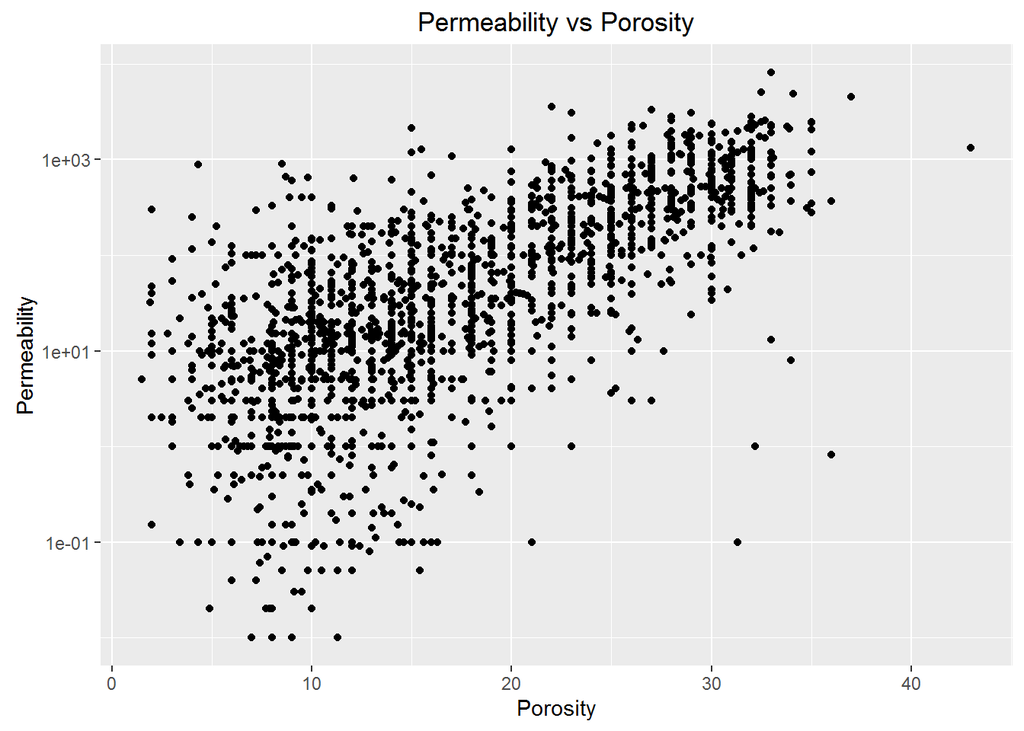

```r
require("dplyr")
require('ggplot2')
require('reshape2')

df = readRDS('../01 Data/dataframe.rds')
porosity_and_permeability <- df %>% dplyr::select(AVPOR, AVPERM) %>% dplyr::arrange(AVPOR)  %>% dplyr::filter(AVPOR > 0 & AVPERM > 0) %>% tbl_df

p1 <- ggplot() +
  coord_cartesian() +
  scale_x_continuous() +
  scale_y_log10() +
  labs(title='Permeability vs Porosity') +
  labs(x="Porosity", y="Permeability") +
  layer(data=porosity_and_permeability,
        mapping=aes(x=as.numeric(AVPOR), y=as.numeric(AVPERM)),
        stat="identity",
        geom="point",
        position=position_jitter(width=0, height=0)
  )
p1
```

## Plot 2 - Data Points vs State

We can plot how much data was collected in each state. We see that Texas and Louisiana had the most data collected.

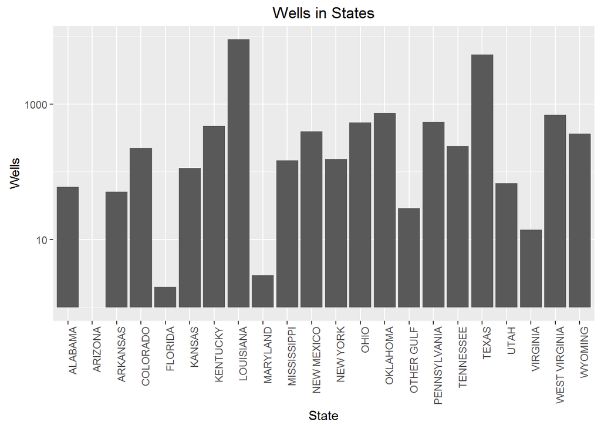

```r
require("dplyr")
require('ggplot2')
require('reshape2')

df = readRDS('../01 Data/dataframe.rds')
wells_in_state <- df %>% group_by(STATE) %>% dplyr::summarise(n = n()) %>% dplyr::arrange(desc(n)) %>% tbl_df


p2 <- ggplot() +
  coord_cartesian() +
  scale_x_discrete() +
  scale_y_log10() +
  labs(title='Wells in States') +
  labs(x="State", y="Wells") +
  layer(data=wells_in_state,
        mapping=aes(x=STATE, y=as.numeric(n)),
        stat="identity",
        geom="bar",
        position=position_jitter(width=0, height=0)
  )

p2 <- p2  + theme(axis.text.x = element_text(angle = 90, hjust = 1))
p2
```

## Plot 3 - Average Porosity and Permeability vs State

We can get the average reservoir properties in the states. We find that Louisiana, Arkansas, and Mississippi have the most desirable reservoir properties.

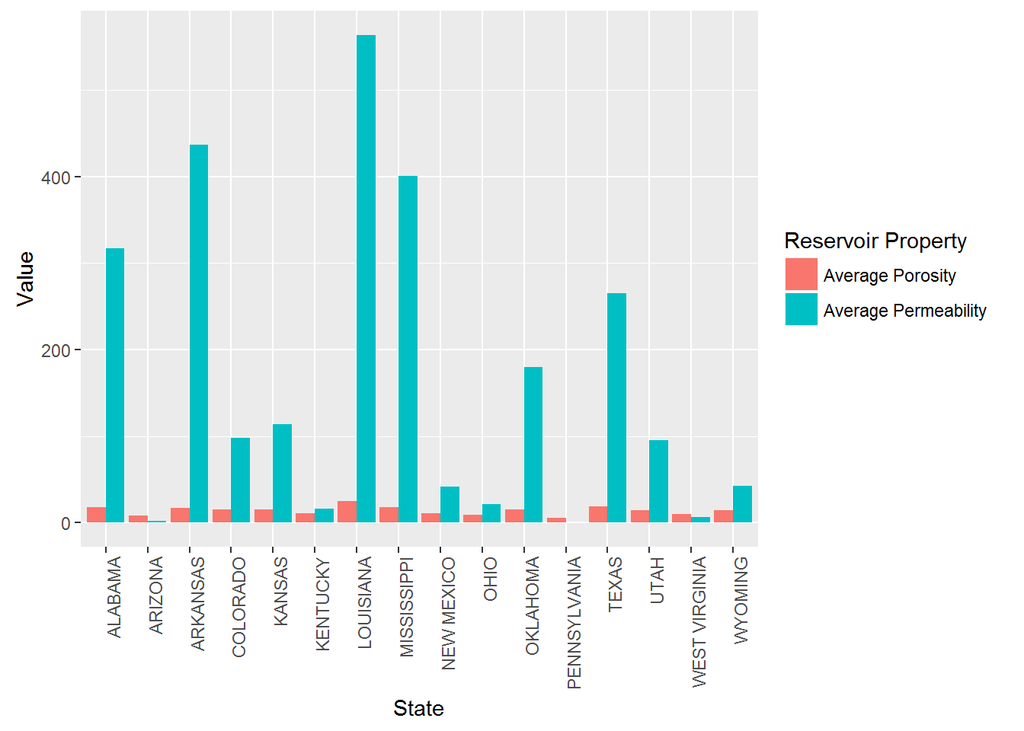

```r
require("dplyr")
require('ggplot2')
require('reshape2')

df = readRDS('../01 Data/dataframe.rds')

averages_by_state <- df  %>% dplyr::select(STATE, AVPOR, AVPERM) %>% dplyr::filter(AVPOR > 0 & AVPERM > 0) %>% group_by(STATE) %>% summarise_each(funs(mean(., na.rm=TRUE)), -STATE)

x = melt(averages_by_state)

plot3 <- ggplot(x,aes(x=STATE,y=value,fill=factor(variable)))+
  geom_bar(stat="identity",position="dodge")+
  scale_fill_discrete(name="Reservoir Property",
                      breaks=c('AVPOR', 'AVPERM'),
                      labels=c("Average Porosity", "Average Permeability"))+
  xlab("State")+ylab("Value")

plot3 <- plot3 + theme(axis.text.x = element_text(angle = 90, hjust = 1))
plot3
```